# Bootstraping_Regrission

# a) Bootstrapping

## 1)

```r
data = airquality$Solar.R
boot_sample = as.list(as.data.frame(replicate(1000, sample(data, 500, replace = T))))
med_sample = (sapply(boot_sample, median, na.rm = T))
```

## 2)

We simply delete first and last 5% of data, remaining data represent the 90% confidence interval.

```r
quantile(med_sample, c(0.05, 0.95))
```

```
 5% 95%
192 220
```

## 3)

```r
med = median(med_sample)
se = sd(med_sample)
err = qt(0.9, length(med_sample) - 1)
ci = c(med - se * err, med + se * err)
ci
```

```
[1] 195.2343 218.7657
```

## 4)

Those are almost equal, I prefer second method

## 5)

There is a problem in loading inference.

# b) Simulation

## 6)

```r
library(msme)
library(COUNT)
ships$Risk <- ifelse(ships$incidents < 10, 'Low', 'High')
```

## 7)

Yes, it does.

But I can’t perform a simulation ;-(

## 8)

No, it isn’t. It is obvious which type B ships count as High Risk ships.

conditions are not satisfied, we need a sample which size be at least 30.

# c) Linear Regression, Multiple Linear Regression

## 9)

There is probably a relation between these two variables, but it isn’t obvious in this plot. I think it’s not possible to say that just by looking at the plot.

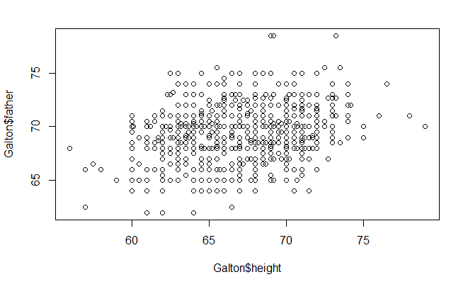

```r
library(mosaicData)
plot(Galton$height, Galton$father)
```

## 10)

These variables have low correlation so, we couldn’t say that there is a strong relation.

```r
cor(Galton$height, Galton$father)
```

```
[1] 0.2753548
```

## 11)

It’s showing that how much height of father impacts on child height.

```r
lm(Galton$height ~ Galton$father, data = Galton)
```

```
Call:
lm(formula = Galton$height ~ Galton$father, data = Galton)

Coefficients:
  (Intercept)  Galton$father
      39.1104         0.3994
```

## 12)

height = 0.3994 * father + 39.1104

Intercept is actually intercept of line equation.

## 13)

```r
father <- data.frame(father = c(70, 75, 80))
predict(lm(height ~ father, data = Galton), father)
```

```
       1        2        3
67.06708 69.06398 71.06089
```

## 14)

```r
lm(height ~ father + mother, data = Galton)
```

```
Call:
lm(formula = height ~ father + mother, data = Galton)

Coefficients:
(Intercept)       father       mother
    22.3097       0.3799       0.2832
```

```r
Galton
```

| family | father | mother | sex | height | nkids |
| --- | --- | --- | --- | --- | --- |
| 1 | 78.5 | 67.0 | M | 73.2 | 4 |
| 1 | 78.5 | 67.0 | F | 69.2 | 4 |
| 1 | 78.5 | 67.0 | F | 69.0 | 4 |
| 1 | 78.5 | 67.0 | F | 69.0 | 4 |
| 2 | 75.5 | 66.5 | M | 73.5 | 4 |
| 2 | 75.5 | 66.5 | M | 72.5 | 4 |
| 2 | 75.5 | 66.5 | F | 65.5 | 4 |
| 2 | 75.5 | 66.5 | F | 65.5 | 4 |
| 3 | 75.0 | 64.0 | M | 71.0 | 2 |
| 3 | 75.0 | 64.0 | F | 68.0 | 2 |

[output cut: 888 more lines]

## 15)

normal distribution of residuals

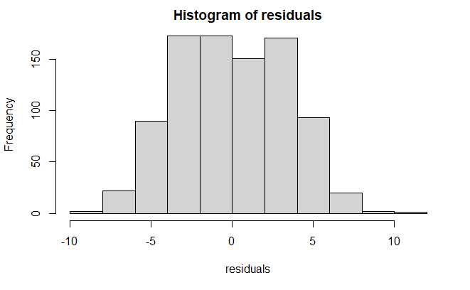

```r
mlr <- lm(height ~ father + mother, data = Galton)
residuals = Galton$height - predict(mlr, Galton)
hist(residuals)
```

## 16)

normal distribution of resudals

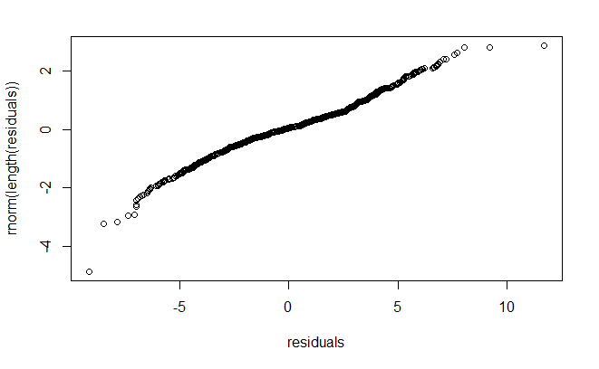

```r
qqplot(residuals, rnorm(length(residuals)))
```

## 17)

Linearity

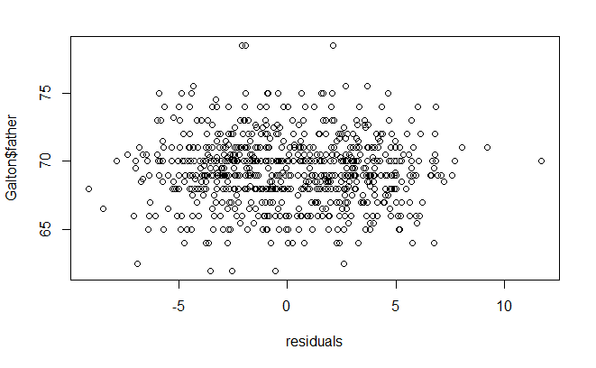

```r
plot(residuals, Galton$father)
```

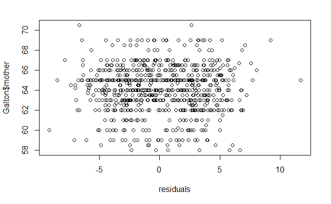

```r
plot(residuals, Galton$mother)
```

## 18)

constant variablity

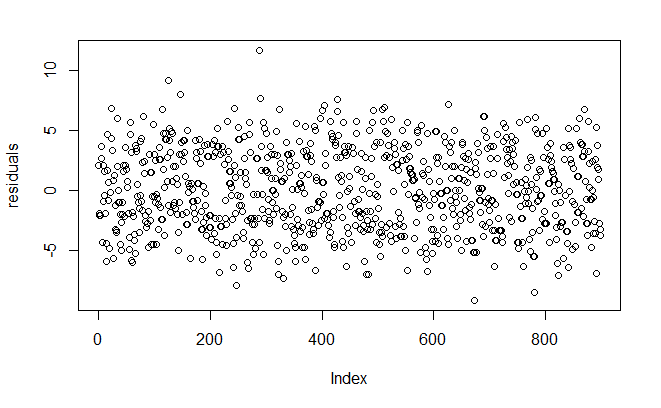

```r
plot(residuals)
```

## 19 & 20)

```r
lm(height ~ father + mother + sex, data = Galton)
```

```
Call:
lm(formula = height ~ father + mother + sex, data = Galton)

Coefficients:
(Intercept)       father       mother         sexM
    15.3448       0.4060       0.3215       5.2260
```

## 21)

By this method, we can just remove nkids.

As you can see residuals distribution is almost normal and they have constant variability.

relation between response variable and explanatory variables are linear.

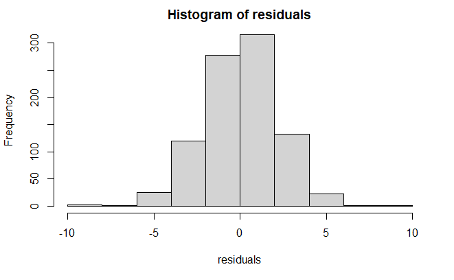

```r
lmr = lm(height ~father + mother + sex, data = Galton)
residuals = Galton$height - predict(lmr, Galton)
hist(residuals)
```

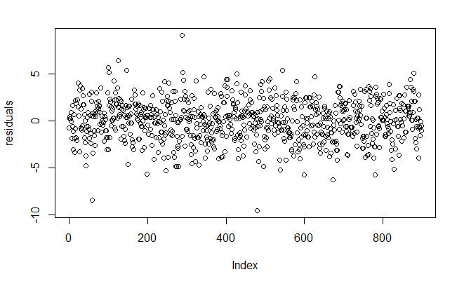

```r
plot(residuals)
```

# d) Logistic Regression

## 22)

```r
library(tidyr)
library(COUNT)
data("titanic")
titanic$survived <- ifelse(titanic$survived == 'yes', T, F)
eq <- glm(survived ~ ., data = titanic, family = binomial(link = 'logit'))
summary(eq)
```

```
Call:
glm(formula = survived ~ ., family = binomial(link = "logit"),
    data = titanic)

Deviance Residuals:
    Min       1Q   Median       3Q      Max
-2.0652  -0.6718  -0.4740   0.7930   2.1175

Coefficients:
               Estimate Std. Error z value Pr(>|z|)
(Intercept)      3.0619     0.2980  10.275  < 2e-16 ***
class2nd class  -1.0106     0.1949  -5.184 2.17e-07 ***
class3rd class  -1.7664     0.1707 -10.347  < 2e-16 ***
ageadults       -1.0556     0.2427  -4.350 1.36e-05 ***
sexman          -2.3695     0.1453 -16.313  < 2e-16 ***
---
Signif. codes:  0 ‘***’ 0.001 ‘**’ 0.01 ‘*’ 0.05 ‘.’ 0.1 ‘ ’ 1

(Dispersion parameter for binomial family taken to be 1)

    Null deviance: 1746.8  on 1315  degrees of freedom
Residual deviance: 1276.2  on 1311  degrees of freedom
AIC: 1286.2

Number of Fisher Scoring iterations: 4
```

## 23)

```r
head(titanic)
```

|  | class | age | sex | survived |
| --- | --- | --- | --- | --- |
| 1 | 1st class | adults | man | TRUE |
| 2 | 1st class | adults | man | TRUE |
| 3 | 1st class | adults | man | TRUE |
| 4 | 1st class | adults | man | TRUE |
| 5 | 1st class | adults | man | TRUE |
| 6 | 1st class | adults | man | TRUE |

```r
smpl = data.frame(class = c('2nd class'), age = 'adults', sex = 'man')
predict(eq, smpl, type = 'response')
```

```
        1
0.2020148
```

## 24)

```r
titanic <- droplevels(titanic)
smpl <- titanic %>% expand(class, age, sex)
smpl
```

| class | age | sex |
| --- | --- | --- |
| 1st class | child | women |
| 1st class | child | man |
| 1st class | adults | women |
| 1st class | adults | man |
| 2nd class | child | women |
| 2nd class | child | man |
| 2nd class | adults | women |
| 2nd class | adults | man |
| 3rd class | child | women |
| 3rd class | child | man |

[output cut: 2 more lines]

```r
smpl$probabilty <- predict(eq, smpl, type = 'response')
smpl
```

| class | age | sex | probabilty |
| --- | --- | --- | --- |
| 1st class | child | women | 0.9552927 |
| 1st class | child | man | 0.6665043 |
| 1st class | adults | women | 0.8814542 |
| 1st class | adults | man | 0.4101873 |
| 2nd class | child | women | 0.8860813 |
| 2nd class | child | man | 0.4211288 |
| 2nd class | adults | women | 0.7302154 |
| 2nd class | adults | man | 0.2020148 |
| 3rd class | child | women | 0.7850784 |
| 3rd class | child | man | 0.2546517 |

[output cut: 2 more lines]

## 25)

```r
titanic$predicted_survied <- ifelse(predict(eq, titanic, type = 'response') >= 0.5, T, F)
sum(titanic$survived == titanic$predicted_survied)
```

```
[1] 1023
```

```r
sum(titanic$survived == titanic$predicted_survied) / length(titanic$survived)
```

```
[1] 0.7773556
```

## 26)

No, it isn’t valid, because there should be a lot of equipment to prevent people from dying in the sea after the Titanic accident.

If these two accidents happened at the same time and with the same available equipment, we could predict the number of survivors of second accident by using first accident’s data.